# Tsetse ddRAD

Gus

2015-04-13

# Overview

### Population Locations

[figure not shown]

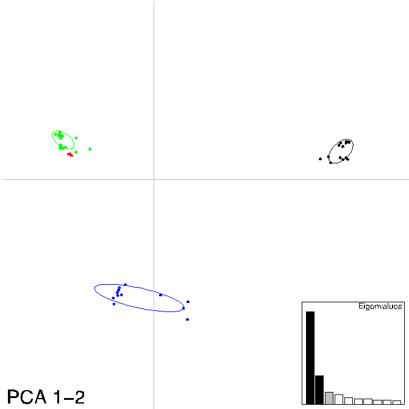

```
PCA: 73, 297 SNPs:

Variance:

PCA1: 0.3%
PCA2: 0.09%
PCA3: 0.04%.
```

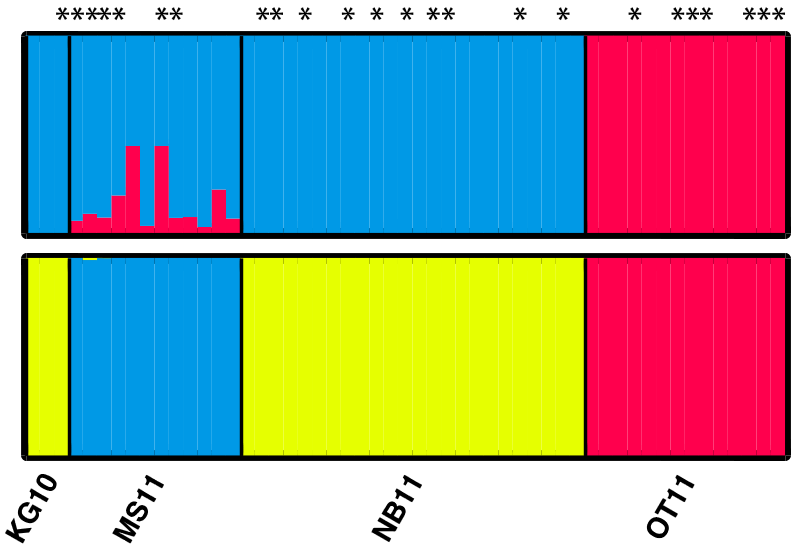

```
FastStructure: 47,997 SNPs that met HWE expectations after
               BH correction.

- A) K=2
- B) K= 3
- Infected individuals indicated with asterisk
```

# Linkage disequilibrium

the co-occurrence of allele-pairs within chromosomes in a population at frequencies unexpected given the overall frequencies of each allele in the population **assuming random assortment** between alleles

- can't assume random assortment
- SNP-pairs separated by differing distances will have different thresholds to define "interesting" values of LD
- The recombination rate of *G. f. fuscipes* is not well established

Grouped SNP-pair into bins of similar separation

50 bp non-overlapping windows

#### Typical mean LD vs Separation

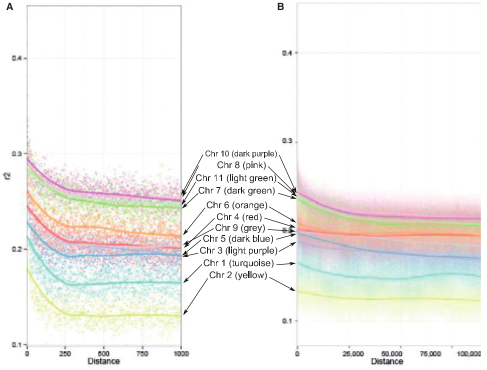

[figure not shown]

#### Our data

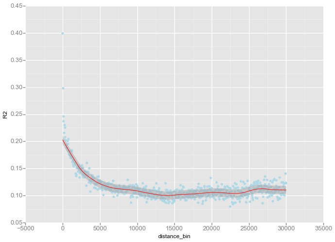

#### Our data (long range)

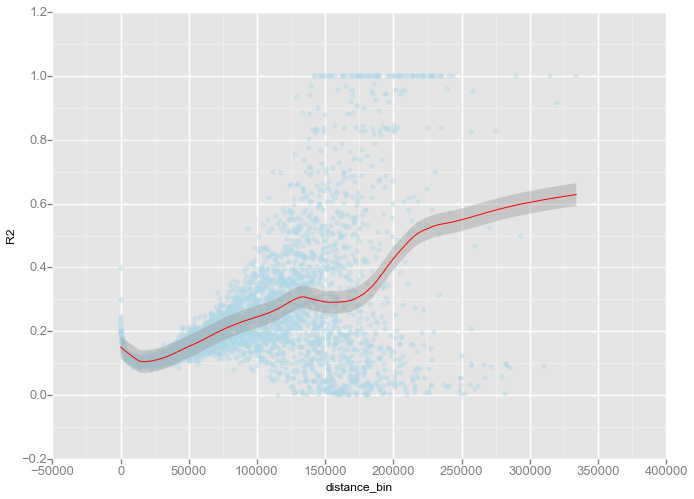

#### What else is going on here?

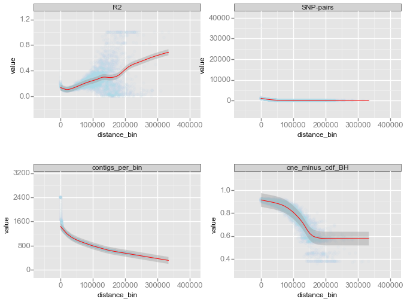

### Must be careful when looking at LD..

Smells Bayesian

What will our model look like?

What do the DATA look like?

*r*<sup>2</sup> distributions when *d* is small:

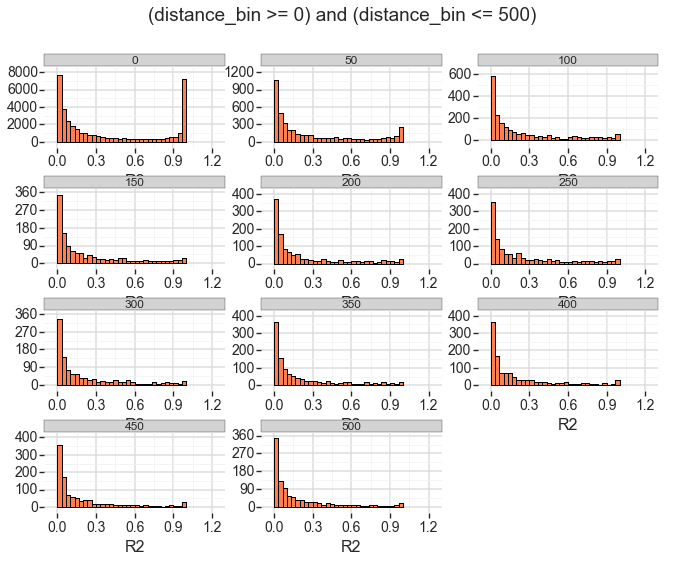

Yes...

Mostly.

*r*<sup>2</sup> distributions when *d* is LARGE:

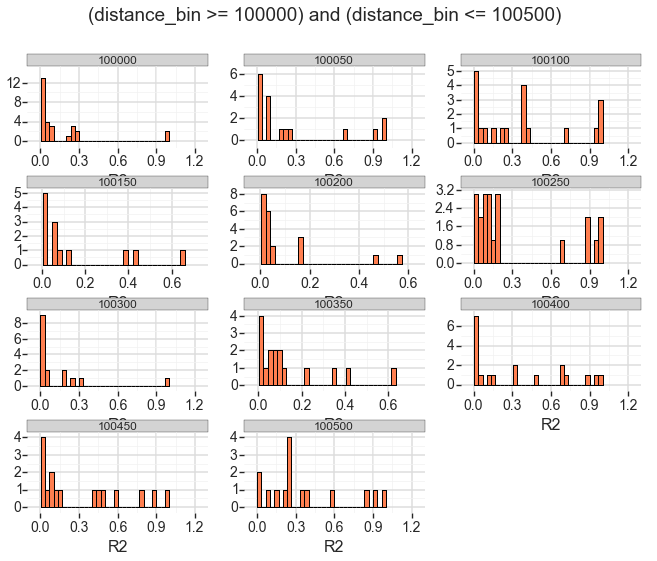

# Brief Update

# Bayesian LD thresholding

How do we build a Bayesian model?!

1. What kind of probability distribution would you use if you wanted to **GENERATE** your data?
2. What are the parameters that the distribution needs to describe itself?
   - **Normal:** *mean* and *standard deviation*
3. What kinds of distributions could be used to **randomly** vary the choice of values to feed into your model's parameters?

What does the data tell us about how our model should look?

- Data is bounded between $0$ and $1$
- Probably not *N*()
- Continuous
- Needs to accommodate two peaks

The Beta distribution mostly fits these qualities:

[figure not shown]

Some of our data have values of 0 or 1.

So I needed to scale our data slightly:

((*x*<sub>*i*</sub> − 0.5) ⋅ *θ*) + 0.5

1. What kind of probability distribution would you use if you wanted to **GENERATE** your data?
   - *Beta*
2. What are the parameters that the distribution needs to describe itself?
   - *Beta: *α* and *β**
   - *both can take any positive value.*
3. What kinds of distributions could be used to **randomly** vary the choice of values to feed into your model's parameters?
   - *We have data so we can inform our prior expectations of the parameter's behavior*

### The model:

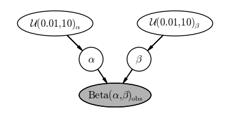

Now for the fun part:

more *MATH* and **CODE** about how this was implemented!!!

[figure not shown]

Just kidding

# Thresholding results

How many SNP-pairs:

```
6735 at p-value of <= 0.05
5284 at <= 0.01.
```

Lowest accepted *r*<sup>2</sup>:

```
0.82
```

How much better than setting threshold at 0.82?

*(rough sensitivity)*

```
80% more *selective*
```

How do the filtered SNP-pairs compare to unfiltered?

Contig length (ALL SNP-pairs):

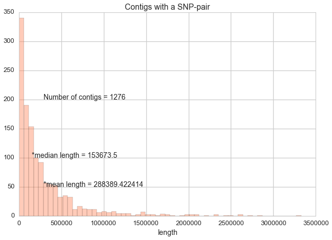

Contig length ( 0.01 SNP-pairs):

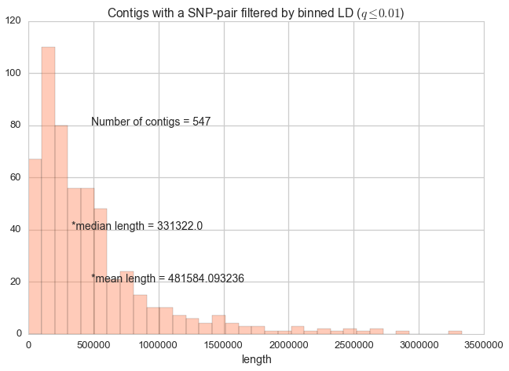

How does p-value change with SNP-pair separation?

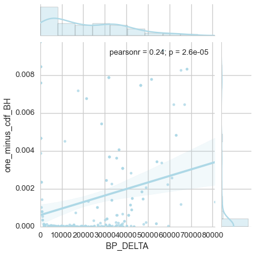

Filtered (0.01) SNP-pairs in windows with Tajima's D $≥ 2$ ?

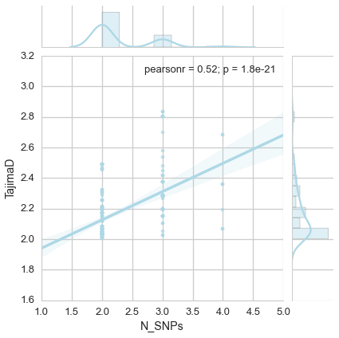